# STAT420-Final-Proj

Dongrong Li

2018-07-29

## Methods

The dataset consists of 354 attributes for 3,748 records, and 15 related attributes are selected for modeling.

```r
planets = read.csv("planets_lite_ns.csv")

#To cleanse data by removing NAs:
planets_good_idx = complete.cases(planets$st_dist, planets$st_optmag, planets$st_teff,
                                  planets$st_mass, planets$st_rad, planets$st_logg,
                                  planets$st_metfe, planets$st_vsini, planets$pl_orbsmax,
                                  planets$pl_orbeccen, planets$pl_bmasse, planets$pl_orbper)

planets_good = planets[planets_good_idx, c("pl_bmasse", "pl_discmethod", "pl_disc", "pl_locale", "st_dist", "st_optmag", "st_teff", "st_mass", "st_rad", "st_logg", "st_metfe", "st_vsini", "pl_orbsmax", "pl_orbeccen", "pl_orbper")]
```

In order to check constant variance assumption, we are using Fitted versus Residuals Plot and Breusch-Pagan test. To assess the normality of errors, we are using normal quantile-quantile (Q-Q) plot and Shapiro–Wilk test. Here are the functions for the Breusch-Pagan test and Shapiro–Wilk test.

```r
get_bp_decision = function(model, alpha) {
  decide = unname(round(bptest(model)$p.value, 2) < alpha)
  list(BP_Test = unname(round(bptest(model)$p.value, 2)),
       Decision = ifelse(decide, "Reject", "Fail to Reject"))
}

get_sw_decision = function(model, alpha) {
  decide = unname(round(shapiro.test(resid(model))$p.value, 2) < alpha)
  list(SW_Test = round(shapiro.test(resid(model))$p.value, 2),
       Decision = ifelse(decide, "Reject", "Fail to Reject"))
}
```

To validate the models by detecting the overfitting issue, we are using the leave-one-out cross-validated (LOOCV) RMSE, which is written as

$$\text{RMSE}_{\text{LOOCV}} = \sqrt{\frac{1}{n}\sum_{i=1}^n \left(\frac{e_{i}}{1-h_{i}}\right)^2},$$

where $h_i$ are the leverages and $e_i$ are the usual residuals. Here we create a specific function for the LOOCV RMSE that will be useful for our model fitting strategy.

```r
get_loocv_rmse = function(model) {
  sqrt(mean((resid(model) / (1 - hatvalues(model))) ^ 2))
}
```

## Results

Below are the scatterplots between pairs of variables in the dataset. We can notice that log-st_rad and st_logg are highly correlated.The second pair with high correlation is log-pl_orbsmax and log-pl_orbper.

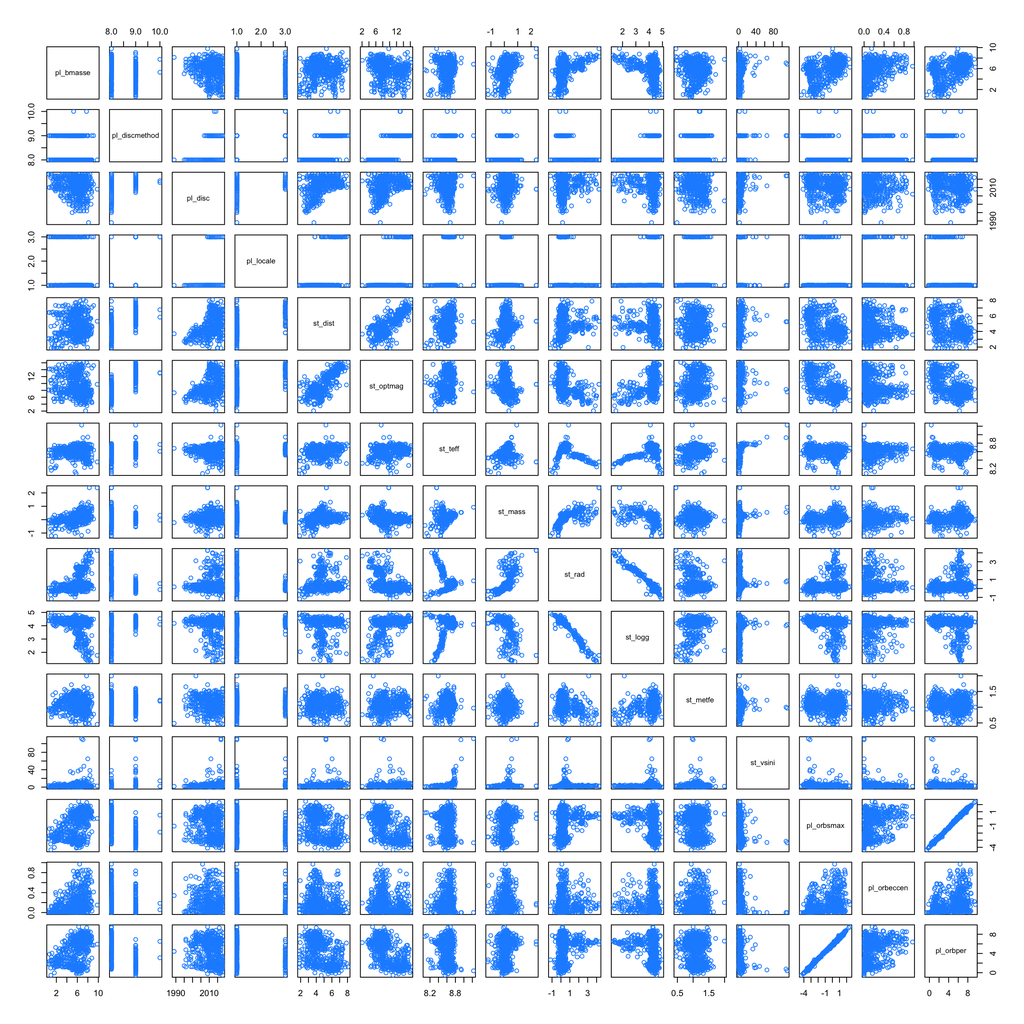

```r
#To see correlations in plot
planets_transf = data.frame(pl_bmasse = log(planets_good$pl_bmasse),
                            pl_discmethod = planets_good$pl_discmethod,
                            pl_disc = planets_good$pl_disc,
                            pl_locale = planets_good$pl_locale,
                            st_dist = log(planets_good$st_dist),
                            st_optmag = planets_good$st_optmag,
                            st_teff = log(planets_good$st_teff),
                            st_mass = log(planets_good$st_mass),
                            st_rad = log(planets_good$st_rad),
                            st_logg = planets_good$st_logg,
                            st_metfe = exp(planets_good$st_metfe),
                            st_vsini = planets_good$st_vsini,
                            pl_orbsmax = log(planets_good$pl_orbsmax),
                            pl_orbeccen = planets_good$pl_orbeccen,
                            pl_orbper = log(planets_good$pl_orbper) )
pairs(planets_transf, col = "dodgerblue")
```

Here we fit an additive model with log-pl_bmasse as the response and the remaining variables in the cleansed dataset as predictors.

```r
#Fit an additive model with all predictors:
md_mass_add = lm(log(pl_bmasse) ~ pl_discmethod + pl_disc + pl_locale + log(st_dist) + st_optmag + exp(st_metfe) + log(st_teff) + log(st_mass) + log(st_rad) + st_logg + st_vsini + log(pl_orbsmax) + pl_orbeccen + log(pl_orbper), data = planets_good)
summary(md_mass_add)
```

```
##
## Call:
## lm(formula = log(pl_bmasse) ~ pl_discmethod + pl_disc + pl_locale +
##     log(st_dist) + st_optmag + exp(st_metfe) + log(st_teff) +
##     log(st_mass) + log(st_rad) + st_logg + st_vsini + log(pl_orbsmax) +
##     pl_orbeccen + log(pl_orbper), data = planets_good)
##
## Residuals:
##    Min     1Q Median     3Q    Max
## -4.091 -0.741  0.025  0.769  4.129
##
## Coefficients:
##                                       Estimate Std. Error t value Pr(>|t|)
## (Intercept)                          213.06295   25.91637    8.22  1.3e-15 ***
## pl_discmethodTransit                   0.82547    0.25136    3.28   0.0011 **
## pl_discmethodTransitTimingVariations   2.10512    0.87475    2.41   0.0164 *
## pl_disc                               -0.10662    0.01146   -9.30  < 2e-16 ***
## pl_localeSpace                        -2.13176    0.18372  -11.60  < 2e-16 ***
## log(st_dist)                           0.33638    0.17786    1.89   0.0591 .
## st_optmag                              0.12407    0.08204    1.51   0.1310
## exp(st_metfe)                          0.37232    0.24703    1.51   0.1323
## log(st_teff)                           0.35237    0.89183    0.40   0.6929
## log(st_mass)                           0.57953    0.30282    1.91   0.0561 .
## log(st_rad)                            0.37667    0.42209    0.89   0.3726
## st_logg                               -0.29092    0.47958   -0.61   0.5443
## st_vsini                               0.03551    0.00731    4.86  1.5e-06 ***
## log(pl_orbsmax)                       -0.00908    0.99415   -0.01   0.9927
## pl_orbeccen                            1.33954    0.27413    4.89  1.3e-06 ***
## log(pl_orbper)                         0.32255    0.66452    0.49   0.6276
## ---
## Signif. codes:  0 '***' 0.001 '**' 0.01 '*' 0.05 '.' 0.1 ' ' 1
##
## Residual standard error: 1.18 on 578 degrees of freedom
## Multiple R-squared:  0.553,  Adjusted R-squared:  0.542
## F-statistic: 47.8 on 15 and 578 DF,  p-value: <2e-16
```

F-test for the regression tells us that the regression is significant, however not all predictors are.

According to the Variance Inflation Factor (VIF) result, there is a huge multicollinearity issue as many of the predictors (e.g. st_optmag and log-pl_orbper) have a VIF greater than 5.

```r
vif(md_mass_add)
```

```
##                 pl_discmethodTransit pl_discmethodTransitTimingVariations
##                                5.888                                1.097
##                              pl_disc                       pl_localeSpace
##                                1.484                                1.803
##                         log(st_dist)                            st_optmag
##                               23.040                               24.932
##                        exp(st_metfe)                         log(st_teff)
##                                1.302                                4.815
##                         log(st_mass)                          log(st_rad)
##                                5.286                               63.221
##                              st_logg                             st_vsini
##                               46.335                                1.480
##                      log(pl_orbsmax)                          pl_orbeccen
##                             1246.256                                1.279
##                       log(pl_orbper)
##                             1226.687
```

Let’s use backward AIC search first. According to the summary results of the AIC selected model, 12 predictors were selected, F test shows the regression is significant, and the adjusted $R^2$ is 0.544.

```r
#Backward AIC search on the MLR fit
md_mass_aic = step(md_mass_add, direction = "backward", trace = 0)
summary(md_mass_aic)
```

```
##
## Call:
## lm(formula = log(pl_bmasse) ~ pl_discmethod + pl_disc + pl_locale +
##     log(st_dist) + st_optmag + exp(st_metfe) + log(st_mass) +
##     log(st_rad) + st_vsini + pl_orbeccen + log(pl_orbper), data = planets_good)
##
## Residuals:
##    Min     1Q Median     3Q    Max
## -4.078 -0.758  0.027  0.768  4.128
##
## Coefficients:
##                                       Estimate Std. Error t value Pr(>|t|)
## (Intercept)                          214.62955   22.53731    9.52  < 2e-16 ***
## pl_discmethodTransit                   0.83265    0.24924    3.34  0.00089 ***
## pl_discmethodTransitTimingVariations   2.12093    0.87225    2.43  0.01533 *
## pl_disc                               -0.10649    0.01124   -9.48  < 2e-16 ***
## pl_localeSpace                        -2.13254    0.18314  -11.64  < 2e-16 ***
## log(st_dist)                           0.37670    0.12488    3.02  0.00267 **
## st_optmag                              0.10465    0.05896    1.77  0.07644 .
## exp(st_metfe)                          0.34294    0.23619    1.45  0.14705
## log(st_mass)                           0.52064    0.19868    2.62  0.00901 **
## log(st_rad)                            0.55457    0.11956    4.64  4.3e-06 ***
## st_vsini                               0.03651    0.00659    5.54  4.6e-08 ***
## pl_orbeccen                            1.35180    0.27123    4.98  8.2e-07 ***
## log(pl_orbper)                         0.31653    0.02967   10.67  < 2e-16 ***
## ---
## Signif. codes:  0 '***' 0.001 '**' 0.01 '*' 0.05 '.' 0.1 ' ' 1
##
## Residual standard error: 1.18 on 581 degrees of freedom
## Multiple R-squared:  0.553,  Adjusted R-squared:  0.544
## F-statistic: 59.9 on 12 and 581 DF,  p-value: <2e-16
```

Here we use backward BIC search to select predictors. According to the summary results of the selected model, 10 predictors were selected and all are significant, and the adjusted $R^2$ is 0.542.

```r
#Backward BIC search on the MLR fit
md_mass_bic = step(md_mass_add, direction = "backward", k = log(length(resid(md_mass_add))), trace = 0)
summary(md_mass_bic)
```

```
##
## Call:
## lm(formula = log(pl_bmasse) ~ pl_discmethod + pl_disc + pl_locale +
##     log(st_dist) + log(st_mass) + log(st_rad) + st_vsini + pl_orbeccen +
##     log(pl_orbper), data = planets_good)
##
## Residuals:
##    Min     1Q Median     3Q    Max
## -4.079 -0.766  0.004  0.785  3.983
##
## Coefficients:
##                                       Estimate Std. Error t value Pr(>|t|)
## (Intercept)                          213.46787   22.35396    9.55  < 2e-16 ***
## pl_discmethodTransit                   0.89608    0.24676    3.63  0.00031 ***
## pl_discmethodTransitTimingVariations   2.22644    0.87322    2.55  0.01104 *
## pl_disc                               -0.10562    0.01115   -9.47  < 2e-16 ***
## pl_localeSpace                        -2.11585    0.18195  -11.63  < 2e-16 ***
## log(st_dist)                           0.56047    0.07349    7.63  9.9e-14 ***
## log(st_mass)                           0.50765    0.19151    2.65  0.00825 **
## log(st_rad)                            0.37992    0.08745    4.34  1.6e-05 ***
## st_vsini                               0.03313    0.00639    5.19  3.0e-07 ***
## pl_orbeccen                            1.39156    0.27036    5.15  3.6e-07 ***
## log(pl_orbper)                         0.30842    0.02952   10.45  < 2e-16 ***
## ---
## Signif. codes:  0 '***' 0.001 '**' 0.01 '*' 0.05 '.' 0.1 ' ' 1
##
## Residual standard error: 1.18 on 583 degrees of freedom
## Multiple R-squared:  0.549,  Adjusted R-squared:  0.542
## F-statistic:   71 on 10 and 583 DF,  p-value: <2e-16
```

We then use stepwise search to select predictors. According to the summary results of the selected model, 11 predictors were selected, F test shows the regression is significant, and the adjusted $R^2$ is 0.543.

```r
#Stepwise search on the MLR fit
md_start = lm(log(pl_bmasse) ~ 1, data = planets_good)
md_mass_both = step(md_start,
                    scope = log(pl_bmasse) ~ pl_discmethod + pl_disc + pl_locale + log(st_dist) + st_optmag + exp(st_metfe) + log(st_teff) + log(st_mass) + log(st_rad) + st_logg + st_vsini + log(pl_orbsmax) + pl_orbeccen + log(pl_orbper),
                    direction = "both",
                    trace = 0)
summary(md_mass_both)
```

```
##
## Call:
## lm(formula = log(pl_bmasse) ~ log(st_mass) + log(pl_orbsmax) +
##     log(st_dist) + pl_locale + pl_disc + st_vsini + pl_orbeccen +
##     pl_discmethod + log(st_rad) + st_optmag, data = planets_good)
##
## Residuals:
##    Min     1Q Median     3Q    Max
## -4.109 -0.743 -0.003  0.785  4.040
##
## Coefficients:
##                                       Estimate Std. Error t value Pr(>|t|)
## (Intercept)                          219.61874   22.46794    9.77  < 2e-16 ***
## log(st_mass)                           0.52060    0.19587    2.66   0.0081 **
## log(pl_orbsmax)                        0.46910    0.04432   10.58  < 2e-16 ***
## log(st_dist)                           0.36317    0.12490    2.91   0.0038 **
## pl_localeSpace                        -2.15298    0.18286  -11.77  < 2e-16 ***
## pl_disc                               -0.10787    0.01121   -9.62  < 2e-16 ***
## st_vsini                               0.03517    0.00658    5.35  1.3e-07 ***
## pl_orbeccen                            1.38765    0.27008    5.14  3.8e-07 ***
## pl_discmethodTransit                   0.81640    0.24890    3.28   0.0011 **
## pl_discmethodTransitTimingVariations   2.15514    0.87231    2.47   0.0138 *
## log(st_rad)                            0.51226    0.11536    4.44  1.1e-05 ***
## st_optmag                              0.11330    0.05906    1.92   0.0556 .
## ---
## Signif. codes:  0 '***' 0.001 '**' 0.01 '*' 0.05 '.' 0.1 ' ' 1
##
## Residual standard error: 1.18 on 582 degrees of freedom
## Multiple R-squared:  0.552,  Adjusted R-squared:  0.543
## F-statistic: 65.1 on 11 and 582 DF,  p-value: <2e-16
```

```r
#Adding two-way interactions
#md_mass_inter = lm(log(pl_bmasse) ~ (pl_discmethod + pl_disc + pl_locale + log(st_dist) + log(st_mass) + log(st_rad) + st_vsini + pl_orbeccen + log(pl_orbper))^2, data = planets_good)
md_mass_inter = step(md_start,
                     scope = log(pl_bmasse) ~ pl_discmethod + pl_disc + pl_locale + log(st_dist) + st_optmag + log(st_mass) + log(st_rad) + exp(st_metfe) + st_vsini + log(pl_orbper) + pl_locale:pl_orbeccen + log(st_mass):st_vsini +  pl_locale:log(st_dist) + log(st_dist):st_vsini + log(st_dist):log(pl_orbper) + st_vsini:log(pl_orbper) + pl_orbeccen:log(pl_orbper) + log(st_rad): st_logg + log(pl_orbper):log(st_mass),
                     direction = "both",
                     trace = 0)

summary(md_mass_inter)
```

```
##
## Call:
## lm(formula = log(pl_bmasse) ~ log(st_mass) + log(pl_orbper) +
##     log(st_dist) + pl_locale + pl_disc + st_vsini + log(st_rad) +
##     pl_discmethod + pl_locale:pl_orbeccen + log(pl_orbper):log(st_dist) +
##     log(pl_orbper):pl_orbeccen + log(st_mass):st_vsini + log(st_rad):st_logg,
##     data = planets_good)
##
## Residuals:
##    Min     1Q Median     3Q    Max
## -3.435 -0.722 -0.043  0.664  4.185
##
## Coefficients:
##                                      Estimate Std. Error t value Pr(>|t|)
## (Intercept)                          208.2572    21.0066    9.91  < 2e-16 ***
## log(st_mass)                           0.8468     0.2090    4.05  5.8e-05 ***
## log(pl_orbper)                         0.7558     0.0858    8.80  < 2e-16 ***
## log(st_dist)                           1.1619     0.1091   10.65  < 2e-16 ***
## pl_localeSpace                        -2.4367     0.1967  -12.39  < 2e-16 ***
## pl_disc                               -0.1040     0.0105   -9.94  < 2e-16 ***
## st_vsini                               0.0779     0.0155    5.04  6.3e-07 ***
## log(st_rad)                            0.8850     0.1474    6.00  3.4e-09 ***
## pl_discmethodTransit                  -0.1086     0.2607   -0.42  0.67719
## pl_discmethodTransitTimingVariations   1.9476     0.8149    2.39  0.01716 *
## pl_localeGround:pl_orbeccen           -2.4968     0.7309   -3.42  0.00068 ***
## pl_localeSpace:pl_orbeccen             2.1206     0.7358    2.88  0.00410 **
## log(pl_orbper):log(st_dist)           -0.1281     0.0201   -6.38  3.6e-10 ***
## log(pl_orbper):pl_orbeccen             0.5740     0.1164    4.93  1.1e-06 ***
## log(st_mass):st_vsini                 -0.0748     0.0231   -3.24  0.00126 **
## log(st_rad):st_logg                   -0.2145     0.0658   -3.26  0.00118 **
## ---
## Signif. codes:  0 '***' 0.001 '**' 0.01 '*' 0.05 '.' 0.1 ' ' 1
##
## Residual standard error: 1.1 on 578 degrees of freedom
## Multiple R-squared:  0.612,  Adjusted R-squared:  0.602
## F-statistic: 60.9 on 15 and 578 DF,  p-value: <2e-16
```

Based on the adjusted $R^2$, LOOCV RMSE results and the number of predictors, among the selected models without interaction added, we prefer the stepwise model even though the results are very close. If we need to select the most accurate model based the adjusted $R^2$ results, the selected interaction model is the one to pick.

```r
diagonostic = data.frame(
              Adj_R2 = c(summary(md_mass_add)$adj,
                         summary(md_mass_aic)$adj,
                         summary(md_mass_bic)$adj,
                         summary(md_mass_both)$adj,
                         summary(md_mass_inter)$adj),
              LOOCV_RMSE = c(get_loocv_rmse(md_mass_add),
                             get_loocv_rmse(md_mass_aic),
                             get_loocv_rmse(md_mass_bic),
                             get_loocv_rmse(md_mass_both),
                             get_loocv_rmse(md_mass_inter)),
              Par_Cnt = c(length(coef(md_mass_add)) - 1,
                          length(coef(md_mass_aic)) - 1,
                          length(coef(md_mass_bic)) - 1,
                          length(coef(md_mass_both)) - 1,
                          length(coef(md_mass_inter)) - 1))
rownames(diagonostic) = c("Additive Model", "Backward AIC Model", "Backward BIC Model", "Stepwise Model", "Interaction Model")
colnames(diagonostic) = c("Adjusted R^2", "LOOCV RMSE", "# of Predictors")
knitr::kable(diagonostic)
```

|  | Adjusted R^2 | LOOCV RMSE | # of Predictors |
| --- | --- | --- | --- |
| Additive Model | 0.5419 | 1.198 | 15 |
| Backward AIC Model | 0.5439 | 1.192 | 12 |
| Backward BIC Model | 0.5415 | 1.194 | 10 |
| Stepwise Model | 0.5431 | 1.193 | 11 |
| Interaction Model | 0.6023 | 1.126 | 15 |

Below are the diagnostic results of the preferred model. According to both Fitted versus Residuals plot and Breusch-Pagan test, we see a small p-value, so we reject the null of homoscedasticity.

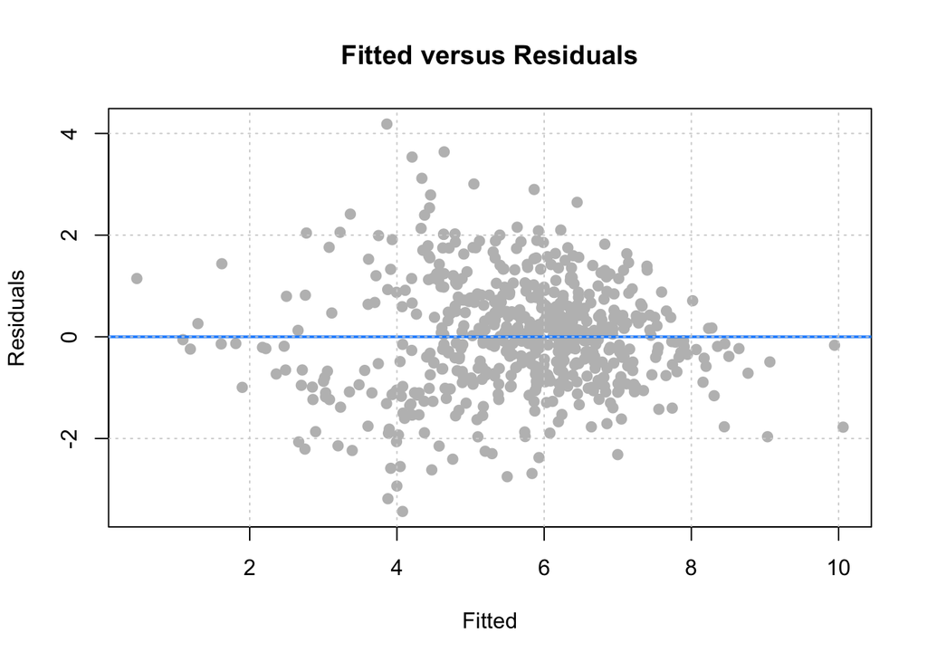

```r
# fitted versus residuals
plot(fitted(md_mass_inter), resid(md_mass_inter),
     col = "grey", pch = 20, cex = 1.5,
     xlab = "Fitted", ylab = "Residuals",
     main = "Fitted versus Residuals")
abline(h = 0, col = "dodgerblue", lwd = 2)
grid()
```

```r
get_bp_decision(md_mass_inter, alpha = 0.01)
```

```
## $BP_Test
## [1] 0
##
## $Decision
## [1] "Reject"
```

From the Q-Q plot and the Shapiro–Wilk test, we would believe the errors follow a normal distribution.

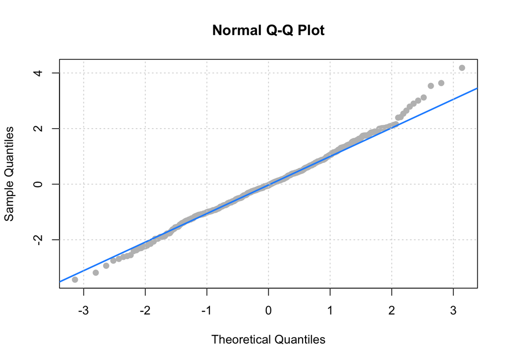

```r
# qq-plot
qqnorm(resid(md_mass_inter), col = "grey", pch = 20, cex = 1.5)
qqline(resid(md_mass_inter), col = "dodgerblue", lwd = 2)
grid()
```

```r
get_sw_decision(md_mass_inter, alpha = 0.01)
```

```
## $SW_Test
## [1] 0.04
##
## $Decision
## [1] "Fail to Reject"
```

## Conclusion

According to the summary table for all the fitted models, even though the model with interaction added has more predictors than the other three selected models, its adjusted $R^2$ is significantly greater and the LOOCV RMSE is much lower than other models. To better model the relationship between our response (planet mass) and predictors, the interaction model is considered to be the best.

By looking at the coefficents of the interaction model, we noticed that the coefficient for log(st_mass) and log(st_rad) are positive. It tells that we find more massive planets orbiting around more massive and larger host stars, vice versa. Therefore, if we want to discover small planets like the Earth, the model suggests we look for planets around smaller stars. The coefficient for pl_disc is negative with a value of -0.1040. This means that as we move forward in time, the discovered planets tend to be less massive. That might be an indicator that we are getting better at finding smaller planets. Negative coefficent of pl_discmethodTransit and positive coefficient of pl_discmethodTransitTimingVariations indicates that Transit as one of the discovoery method tends to discover smaller planets than Transit Timing Variations. The coefficent of pl_localeSpace is -2.4367, which indicates that planet search via space tends to find smaller planets than ground.